# Predicting Exercise Quality with Sensor Data

Zain Naboulsi

2023-05-4

## Abstract

Activity recognition research has primarily centered on identifying different activities, or predicting “which” action occurred at a specific moment. However, the execution quality, or the “how (well),” has been largely overlooked, even though it can offer valuable insights for numerous applications. In this work, we focus on detecting execution mistakes as a vital aspect of qualitative activity recognition.

Thanks to devices like Jawbone Up, Nike FuelBand, and Fitbit, collecting extensive personal activity data has become affordable and accessible. These devices are part of the quantified self movement, where individuals regularly monitor various aspects of their lives to improve their well-being, discover behavioral patterns, or simply because they enjoy technology. While people often track the quantity of an activity, assessing its quality remains rare.

In this project, we aim to evaluate the quality of barbell lifts using data from accelerometers placed on participants’ belts, forearms, arms, and dumbbells. The six participants performed barbell lifts correctly and incorrectly in five different manners. We demonstrate our approach to assessing and providing feedback on weightlifting exercises using a sensor-based technique for qualitative activity recognition in this study.

## Data Cleaning

### Unrelated Variables

Following that, we identified and removed variables that are unrelated to the analysis being conducted. By excluding these variables, the cleaned dataset becomes more focused and relevant to our study. In this case the variables removed were “X”,“user_name”, “raw_timestamp_part_1”, “raw_timestamp_part_2”, “cvtd_timestamp”, “new_window”, and “num_window”

### Factor Conversion

Lastly, we ensure that the variable, “classe,” is converted to a factor data type. This conversion is essential for certain statistical methods and analyses that will be performed later on in the study.

```
## Dimensions of original data:
##  19622 160
```

```
## Dimensions of clean data:
##  19622 86
```

## Feature Selection

In order to identify the most relevant features we used the random forest algorithm for predicting the target variable, “classe”. This process is intended to enhance the performance and interpretability of the model.

A random forest model was trained using our cleaned dataset, with the target variable “classe” and all other variables as predictors. Once the model is fitted, the importance scores of the variables are used to select the top 20 variables.

```
##  [1] "roll_belt"            "yaw_belt"             "pitch_forearm"
##  [4] "magnet_dumbbell_z"    "pitch_belt"           "magnet_dumbbell_y"
##  [7] "roll_forearm"         "magnet_dumbbell_x"    "accel_belt_z"
## [10] "accel_dumbbell_y"     "magnet_belt_y"        "magnet_belt_z"
## [13] "roll_dumbbell"        "accel_dumbbell_z"     "roll_arm"
## [16] "accel_forearm_x"      "gyros_belt_z"         "magnet_forearm_z"
## [19] "total_accel_dumbbell" "magnet_arm_x"         "classe"
```

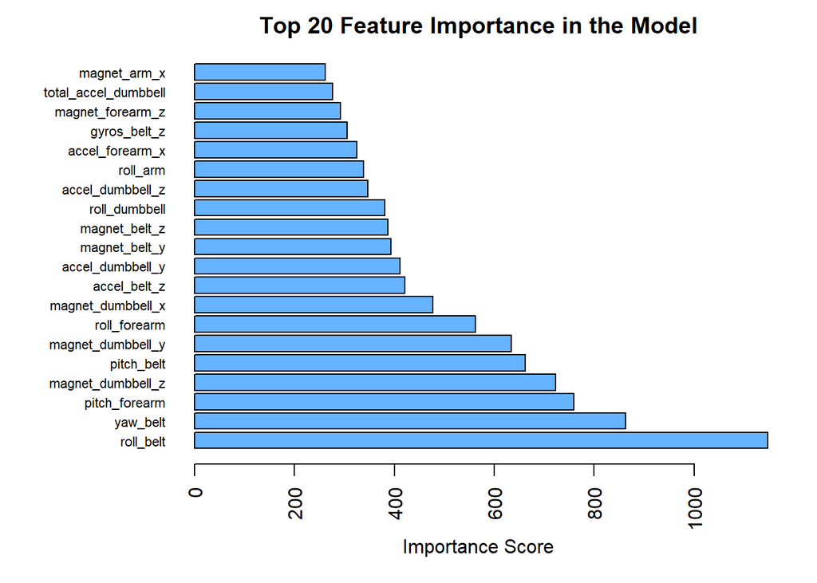

## Training and Inital Testing Data Sets

To provide accuracy in selecting our prediction models, we took the original train data and split it into training (70%) and testing (30%) sets. Setting aside our original test data file for the final run of our models after selection.

## Models

### Model Selection

Given the wealth of prediction models available, we decided to randomly pick four for evaluation to determine accuracy. The results were as follows: Random Forest (99.3%), XGBoost (99.2%), k-Nearest Neighbors (90.8%), and Naive Bayes (74.1%).

### Expected Out of Sample Error

The expected out of sample error was calculated for each model. The values below represent the proportion of incorrect predictions that each model is expected to make on new data. Specifically:

- The Random Forest (rf) model has an expected out-of-sample error of approximately 0.0111, meaning it is expected to make incorrect predictions for about 1.11% of new data points.
- The Extreme Gradient Boosting (xgb) model has an expected out-of-sample error of approximately 0.0100, meaning it is expected to make incorrect predictions for about 1.00% of new data points.
- The k-Nearest Neighbors (knn) model has an expected out-of-sample error of approximately 0.1076, meaning it is expected to make incorrect predictions for about 10.76% of new data points.
- The Naive Bayes (nb) model has an expected out-of-sample error of approximately 0.2556, meaning it is expected to make incorrect predictions for about 25.56% of new data points.

```
## Expected Out of Sample Error
##  0.01106439 0.01004518 0.1075933 0.2555852
```

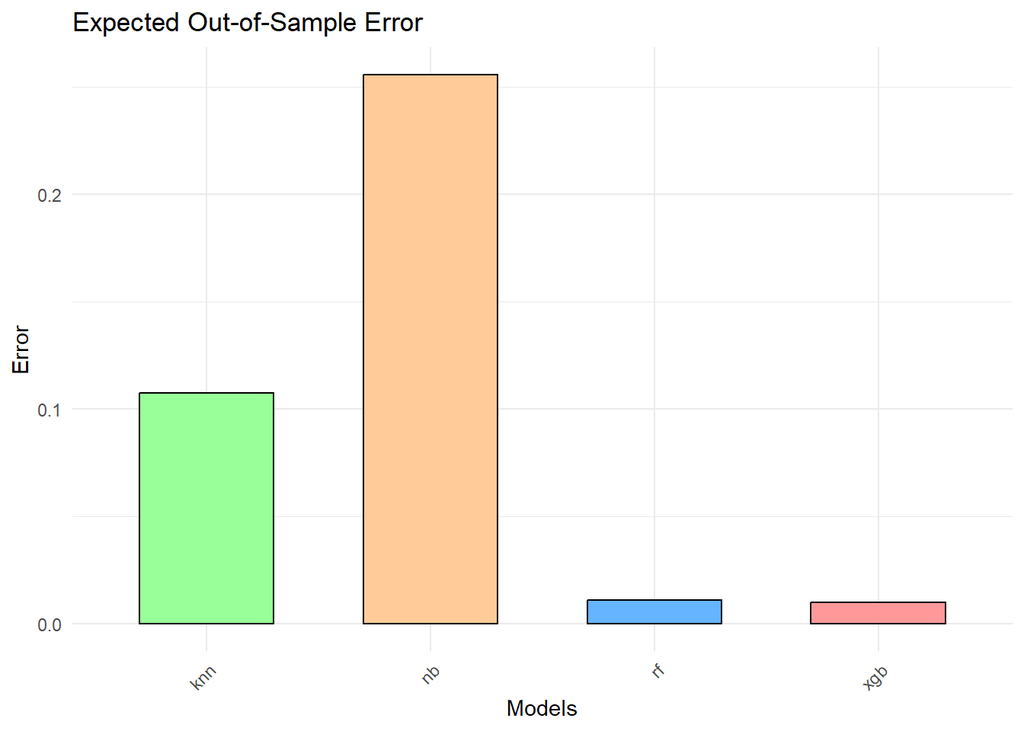

### Cross Validation

Through the implementation of cross-validation, we opted for a more reliable evaluation of the models’ capabilities to handle previously unencountered data. This process minimizes the likelihood of overfitting and offers a better assessment of how well these models are expected to perform with new data.

### Picking the Best Combination of Models

They were then evaluated through every combination of models to find the best mix with the most accuracy. Ultimately, the joining of Random Forest and XGBoost produced an estimated accuracy of 99.3%. While this matches the accuracy of Random Forest alone, we felt that having more than one model was ideal.

Additionally, While both methods rely on decision trees, they utilize distinct strategies for amalgamating and refining these structures. Random Forest generates numerous trees independently and combines their forecasts, whereas XGBoost constructs trees sequentially, learning from prior tree errors.

Owing to these variances, RF and XGB were deemed diverse enough for inclusion in a composite model. Merging their estimations should enhance overall performance and reduce overfitting.

```
## Best combination: rf, xgb
##  Best accuracy: 0.993373
```

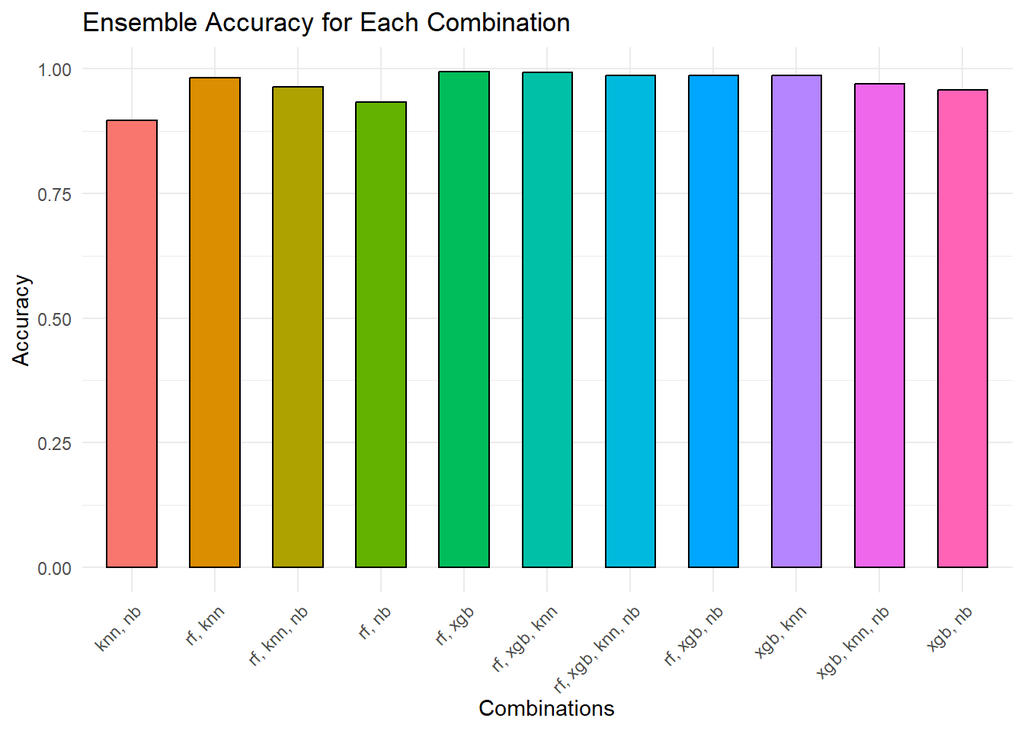

## Prediction on the Original Test Data Set

### Methodology

We employed an ensemble learning strategy to predict class labels for a new set of test instances. Our ensemble consisted of two well-regarded machine learning algorithms: Random Forest (RF) and eXtreme Gradient Boosting (XGBoost). Ensemble learning is a powerful approach that combines predictions from multiple models to enhance overall predictive accuracy and mitigate the risk of overfitting.

### Execution

The test dataset contained 20 instances, each represented by a set of features. Our goal was to predict the class label for each instance. To achieve this, we used the trained RF and XGBoost models to generate probability predictions for each class. We then computed the average of these probabilities to obtain a consensus prediction. By selecting the class with the highest average probability, we determined the final prediction for each test instance:

```
## Predictions for final test set:  B A B A A E D B A A B C B A E E A B B B
```

- Class A: 7 occurrences
- Class B: 8 occurrences
- Class C: 1 occurrence
- Class D: 1 occurrence
- Class E: 3 occurrences

## Conclusion

In conclusion, our results indicate that Class A (performed exactly according to the specification) and Class B (throwing the elbows to the front) were the most commonly predicted classes in the result set, with 7 and 8 occurrences, respectively. Class C (lifting the dumbbell only halfway) and Class D (lowering the dumbbell only halfway) were the least common, each with only 1 occurrence. Class E (throwing the hips to the front) had 3 occurrences in the result set.

Our ensemble learning strategy effectively leveraged the strengths of both RF and XGBoost algorithms to produce accurate predictions for the test instances. By averaging class probability predictions, we obtained a robust set of predictions that demonstrated the value of ensemble learning. This study underscores the potential of ensemble learning for enhancing predictive performance in various research efforts.

# Appendix

## Citations

Ugulino, W.; Cardador, D.; Vega, K.; Velloso, E.; Milidiu, R.; Fuks, H. Wearable Computing: Accelerometers’ Data Classification of Body Postures and Movements. *Proceedings of 21st Brazilian Symposium on Artificial Intelligence. Advances* *in Artificial Intelligence - SBIA 2012*. In: Lecture Notes in Computer Science. , pp. 52-61. Curitiba, PR: Springer Berlin / Heidelberg, 2012. ISBN 978-3-642-34458-9. DOI: 10.1007/978-3-642-34459-6_6.

Velloso, Eduardo & Bulling, Andreas & Gellersen, Hans & Ugulino, Wallace & Fuks, Hugo. (2013). Qualitative activity recognition of weight lifting exercises. *ACM International Conference Proceeding Series*. 10.1145/2459236.2459256.

## Further Study

While we were able to predict correct and incorrect exercises post-facto. It would be interesting to see if the sensor data and models could be used in real-time or near real-time to provide instant feedback to the participant.

## Source Code

```r
# set a seed in case we use any random values
set.seed(1337)

# Set the names of the packages and libraries you want to install
required_libraries <- c("magrittr", "randomForest", "caret", "gbm", "xgboost", "kernlab", "e1071", "combinat")

# Install missing packages and load all required libraries
for (lib in required_libraries) {
  if (!requireNamespace(lib, quietly = TRUE)) {
    install.packages(lib)
  }
  library(lib, character.only = TRUE)
}


# Assuming the dataset is in a CSV format, load the dataset
data <- read.csv("pml-training.csv")

# Remove variables with missing values
threshold <- 0.9 * nrow(data)
data_clean <- data[, colSums(is.na(data)) < threshold]

# Remove unnecessary variables
unrelated_vars <- c("X","user_name", "raw_timestamp_part_1",
                    "raw_timestamp_part_2", "cvtd_timestamp", "new_window",
                    "num_window")
data_clean <- data_clean[ , !(names(data_clean) %in% unrelated_vars)]

# Ensure the response variable is a factor
data_clean$classe <- as.factor(data_clean$classe)


cat("Dimensions of original data:\n", dim(data))

cat("Dimensions of clean data:\n", dim(data_clean))

# Feature selection using randomForest
set.seed(1337)
rf <- randomForest(classe ~ ., data = data_clean, importance = TRUE)


# Extract variable importance
importance_matrix <- as.data.frame(rf$importance)
rownames(importance_matrix) <- colnames(data_clean)[!colnames(data_clean)
                                                    %in% "classe"]

# Order variables by importance
importance_order <- order(importance_matrix$MeanDecreaseGini, decreasing = TRUE)

# Select top N most important variables
N <- 20
selected_vars <- rownames(importance_matrix)[importance_order[1:N]]
data_selected <- data_clean[, c(selected_vars, "classe")]

# Check the selected variables
names(data_selected)

# create a graph to show importance visually
# Sort the importance scores in decreasing order
importance_sorted <- importance_matrix[order(importance_matrix$MeanDecreaseGini, decreasing = TRUE),]

# Limit the number of features displayed to the top 20 most important features
N <- 20
importance_topN <- importance_sorted[1:N, ]

# Adjust the margins of the plot
par(mar = c(5, 8, 2, 2) + 0.1)

# Create a horizontal bar plot of the sorted variable importance scores
barplot(importance_topN$MeanDecreaseGini, names.arg = rownames(importance_topN),
        horiz = TRUE, las = 2, cex.names = 0.7,
        xlab = "Importance Score",
        ylab = "",
        col = "#66b3ff",
        border = "black")

# Add a title to the plot
title("Top 20 Feature Importance in the Model", font.main = 2)

# Reset the plot parameters to default
par(mar = c(5, 4, 4, 2) + 0.1)

# Split the dataset into training (70%) and testing (30%) sets
set.seed(1337)
trainIndex <- createDataPartition(data_selected$classe, p = 0.7, list = FALSE)
train <- data_selected[trainIndex, ]
test <- data_selected[-trainIndex, ]


# Set up cross-validation
trControl <- trainControl(method = "cv", number = 5)

# Train models and evaluate performance
model_names <- c("rf", "xgb", "knn", "nb")
methods <- c("rf", "xgbTree", "knn", "naive_bayes")

results <- list()
resampling_results <- list()

for (i in 1:length(model_names)) {
  set.seed(1337)

  # Check if the current model is "xgb" and apply the unique setting
  if (model_names[i] == "xgb") {
    model <- caret::train(classe ~ ., data = train, method = methods[i],
                          trControl = trControl, verbose = FALSE, verbosity = 0)
  } else {
    model <- caret::train(classe ~ ., data = train, method = methods[i],
                          trControl = trControl)
  }

  pred <- predict(model, test)
  accuracy <- mean(pred == test$classe)
  results[[model_names[i]]] <- list(model = model, accuracy = accuracy)

  # Store resampling results for each model
  resampling_results[[model_names[i]]] <- model$resample
}

# Calculate expected out-of-sample error for each model
expected_out_of_sample_error <- sapply(resampling_results,
                                       function(x) mean(1 - x$Accuracy))

# Print expected out-of-sample error for each model
cat("Expected Out of Sample Error", "\n", expected_out_of_sample_error)

# Convert 'expected_out_of_sample_error' to a data frame
expected_error_df <- data.frame(
  Model = names(expected_out_of_sample_error),
  Error = as.numeric(expected_out_of_sample_error)
)

# Create a bar plot
ggplot(expected_error_df, aes(x = Model, y = Error, fill = Model)) +
  geom_bar(stat = "identity", color = "black", width = 0.6) +
  scale_fill_manual(values = c("rf" = "#66b3ff", "xgb" = "#ff9999", "knn" = "#99ff99", "nb" = "#ffcc99")) +
  theme_minimal() +
  theme(
    axis.text.x = element_text(angle = 45, hjust = 1),
    legend.position = "none"
  ) +
  labs(
    title = "Expected Out-of-Sample Error",
    x = "Models",
    y = "Error"
  )



# Function to create ensemble for a given combination of models
get_ensemble_accuracy <- function(models, results, test) {
  ensemble_preds <- list()

  for (model_name in models) {
    prob_preds <- predict(results[[model_name]]$model, test, type = "prob")
    # Ensure that the columns are ordered consistently
    prob_preds <- prob_preds[, sort(colnames(prob_preds))]
    ensemble_preds[[model_name]] <- prob_preds
  }

  avg_probs <- Reduce("+", ensemble_preds) / length(ensemble_preds)
  final_pred <- colnames(avg_probs)[max.col(avg_probs, ties.method = "first")]
  ensemble_accuracy <- mean(final_pred == test$classe)

  return(ensemble_accuracy)
}

library(ggplot2)

# Create an empty data frame to store ensemble results
ensemble_results <- data.frame()

# Iterate through all possible combinations of models
for (num_models in 2:length(model_names)) {
  combinations <- combn(model_names, num_models, simplify = FALSE)

  for (combination in combinations) {
    ensemble_accuracy <- get_ensemble_accuracy(combination, results, test)

    # Store the combination and accuracy in the ensemble_results data frame
    ensemble_results <- rbind(ensemble_results, data.frame(
      Combination = paste(combination, collapse = ", "),
      Accuracy = ensemble_accuracy
    ))
  }
}

# Find the best combination and accuracy
best_accuracy <- max(ensemble_results$Accuracy)
best_combination <- ensemble_results$Combination[which.max(ensemble_results$Accuracy)]

cat("Best combination:", best_combination, "\n",
    "Best accuracy:", best_accuracy, "\n")

# Create a bar plot of ensemble accuracies
ggplot(ensemble_results, aes(x = Combination, y = Accuracy, fill = Combination)) +
  geom_bar(stat = "identity", color = "black", width = 0.6) +
  theme_minimal() +
  theme(
    axis.text.x = element_text(angle = 45, hjust = 1),
    legend.position = "none"
  ) +
  labs(
    title = "Ensemble Accuracy for Each Combination",
    x = "Combinations",
    y = "Accuracy"
  )


# load the final test dataset
new_test_data <- read.csv("pml-testing.csv")

# Get probability predictions for each class using the trained models
rf_probs <- predict(results[["rf"]]$model, new_test_data, type = "prob")
xgb_probs <- predict(results[["xgb"]]$model, new_test_data, type = "prob")

# Ensure that the columns are ordered consistently
rf_probs <- rf_probs[, sort(colnames(rf_probs))]
xgb_probs <- xgb_probs[, sort(colnames(xgb_probs))]

# Average the class probabilities
avg_probs <- (rf_probs + xgb_probs) / 2

# Select the class with the highest probability as the final prediction
final_pred <- colnames(avg_probs)[max.col(avg_probs, ties.method = "first")]

# The variable final_pred now contains the final predictions for the new_test_data
cat("Predictions for final test set: ", final_pred)
```